# Trees and Ensambles

Davide Viviano

## Review

Until now we have studied for **regression**:

- Linear models
- Shrinkage methods
- Splines
- Kernel Smoothers and local polynomials

and for **classification**:

- Logistic regression
- Gaussian Bayesian Classiffier
- K-Nearest Neighbours

When these models work and when not? What are the main assumptions of each model?

**Regression trees: a semi-parametric model**

The objective function is:

$$\sum_{i=1}^n (y_i - f(x_i))^2$$

But it is infeasible to minimize. The idea is to use the following greedy algorithm:

$$\underset{s,p}{\operatorname{min}}[\underset{d_1}{\operatorname{min}} \sum_{x_i \in R_1(s,p)} (y_i - d_1)^2 + \underset{d_2}{\operatorname{min}} \sum_{x_i \in R_2(s,p)} (y_i - d_2)^2]$$

Where $R_1 = \{x_{i,p} < s\}$ and $R_2 = \{x_{i,p} > s\}$

The final predictor has the following form:

$$\hat{f}(x) = \sum_{m=1}^M d_mI(x \in R_M)$$

$I(x \in R_M) = 1$ if $x_{i,p} \in R_M$, $0$ otherwise. It is easy to shown that:

$$d_m= ave(y_i|x_i \in R_m)$$

**Semi-parametric model:**

- Greedy algorithm to find the best split (sub-optimal solution)
- Squared error minimization for each node

**Example**

```r
load("./data/fatalities.rda")
## Predict the wage with IQ and years of experience
library(tree)
cc <- tree.control(nobs=nrow(fatalities), mincut=15, minsize=30,
                    mindev=0.02) ## Look for other values!
tr <- tree(fatal ~ beertax + unemp, data=fatalities, split='deviance', control=cc)
```

**Fatalities Rate:**

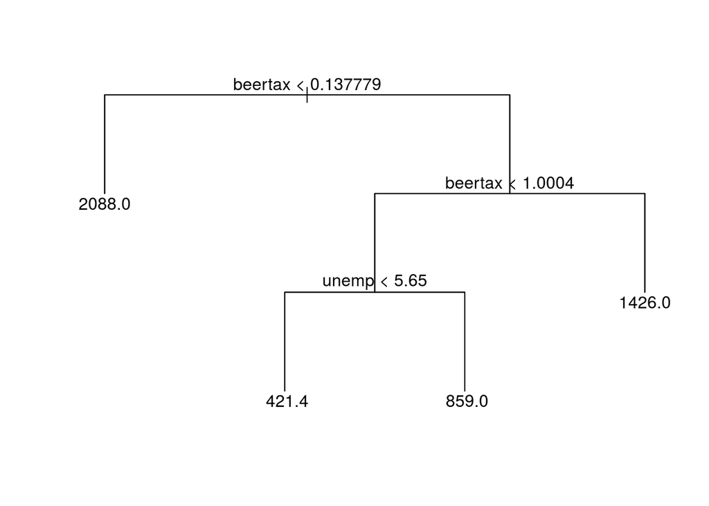

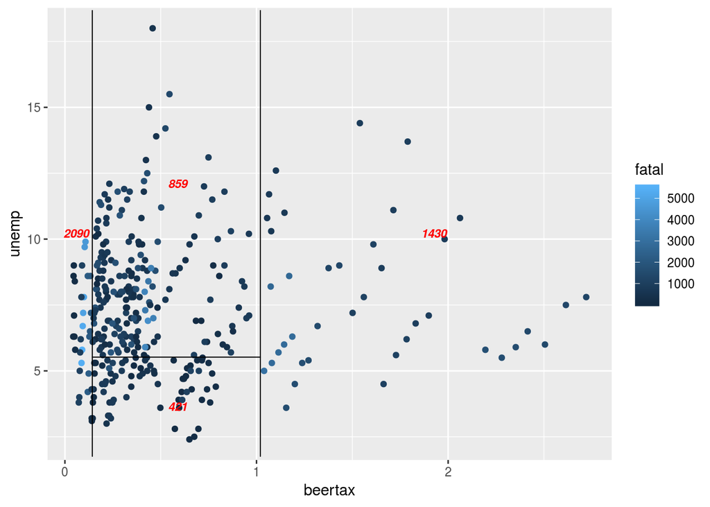

**Larger tree?**

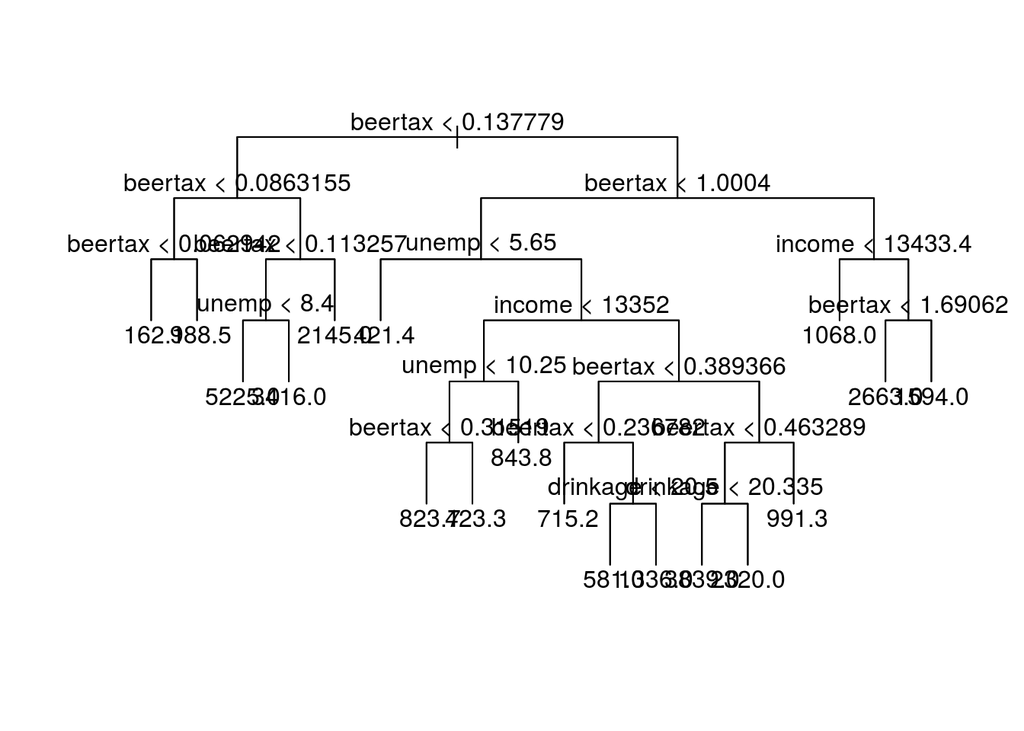

```r
cc <- tree.control(nobs=nrow(fatalities), mincut=2, minsize=4,
                    mindev=exp(-5)) ## Look for other values!
tr <- tree(fatal ~ beertax + unemp + income  + drinkage, data=fatalities, split='deviance', control=cc)
plot(tr, type='uniform')
text(tr, pretty=TRUE)
```

## Issues

- How many splits
- How many observations in each node

The size of the tree represents a crucial issue. Consequently we choose the trees adaptively.

## Pruning algorithm

**Algorithm:**

- Build a large tree (overfitting)
- Generate n subtree by removing each terminal node
- Find the out-of-sample MSE of each sub-tree
- Choose the one with smallest MSPE
- Continue until convergence

Is it a suboptimal solution?

**More precisely:**

$N_m$ the number of observations in each node, $|T|$ the number of terminal nodes of a the tree, $MSE_m$ = $\frac{1}{N_m}\sum_1^m(y_i - \bar{y}_m)^2$ $\forall$ $y_i \in R_m$. The objective function to minimize (cost-complexity criterion) is:

$$C_\gamma(T) = \sum_{m=1}^{|T|}N_mMSE_m(T)+ \gamma|T|$$

For each sub-tree $T_\alpha$ $\subset$ $T_0$ we find the one that minimizes $C_\alpha(T)$, where alpha is the usual parameter of a generalized ridge regression.If $\alpha = 0$ then we get a full tree $T_0$. Note that $\alpha$ is chosen using the *out-of-sample* MSE.

**Example:**

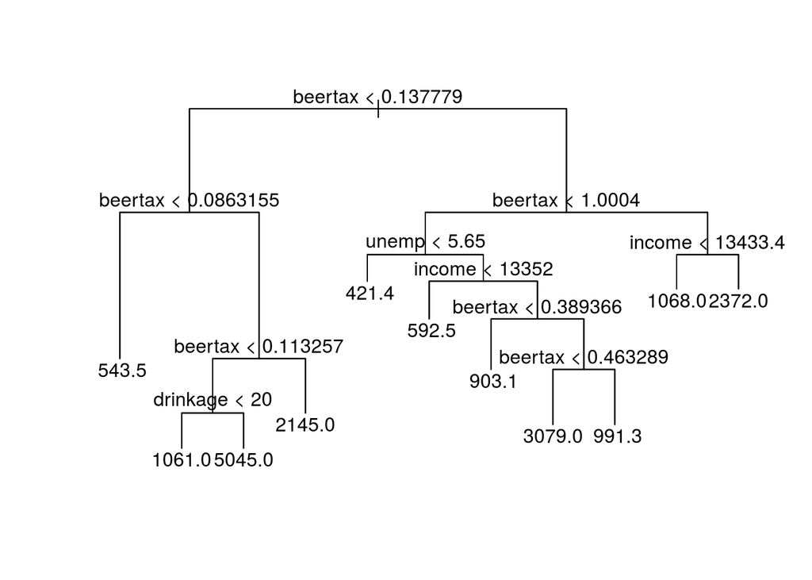

```r
## Overfitting

cc <- tree.control(nobs=nrow(fatalities), mincut=1, minsize=2,
                    mindev=exp(-30)) ## Look for other values!
full <- tree(fatal ~ beertax + unemp + income  + drinkage, data=fatalities, split='deviance', control=cc) ## Full model


## Pruning back

set.seed(1322)
## Use cross validation on the full tree
tree.cv <- cv.tree(full)

## Find the number of nodes with minimum CV deviance: select the smallest

ko <- max(tree.cv$k[min(tree.cv$dev)==tree.cv$dev])

## Prune back
pruned.tree <- prune.tree(full, k=ko)

plot(pruned.tree)
text(pruned.tree,pretty=FALSE)
```

## Exercise

We are interested in predicting the wage of people controlling for several covariates such as the IQ, the education, the experience, etc. We are asked to study the effects of these variables, select some of them and report the resuts. To do so, we believe that trees may have not only a good performance, but also can be easy to visulize.

Use lwage as dependet variable and limit your attention only from the second column to the 16th columns of data wage2, available online. Select three variables. What variable would you use for the regression? Which tree would you select? Compute the out-of-sample MSE of your tree (use *correctly* cross-validation).

**Challenge:**

- Could you provide also the standard deviation of the cross validated MSE of your tree?

```r
load("./data/wage2.rda")

## Selected IQ, educ and exper: you should check other results

## Cross validation for a pruned tree
set.seed(123)

  n <- dim(wage2)[1]
  k <- 10

  ii <- sample(rep(1:k, length= n))

  pr.1 <- rep(NA, n)

  for (j in 1:k){
    hold <- (ii == j)
    train <- (ii != j)
    cc <- tree.control(nobs=nrow(wage2[train,]), mincut=1, minsize=2,
                    mindev=exp(-30)) ## Look for other values!
    full <- tree(lwage ~ IQ + educ + exper, data=wage2[train,], split='deviance',     control=cc)
    tree.cv <- cv.tree(full)
    ko <- max(tree.cv$k[min(tree.cv$dev)==tree.cv$dev])
    pruned.tree <- prune.tree(full, k=ko)
    pr.1[hold] <- predict(pruned.tree, newdata=wage2[hold,])

}

mean((pr.1-wage2$lwage)^2)
```

```
## [1] 0.1653276
```

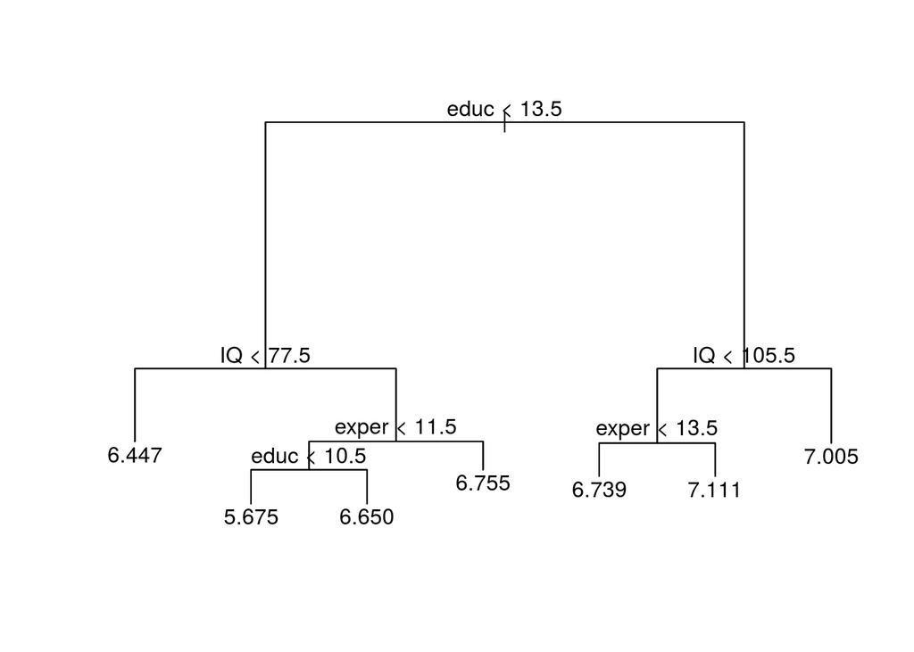

## Bootstrap

Let’s assume that the observations in our sample have been randomly drawn from the true population. The training set is $Z = (z_1,z_2, ...,z_n)$ with n observations and $z_i = (X_i, y_i)$.

We can draw with replacement observations from the initial sample and build new samples. It can be shown that the distribution of each of them asyntodically converges to the true distribution under the assumption of randomization of the initial sample.

Consequently we can compute each statistic $\hat{\gamma} = \frac{1}{B} \sum_{i=1}^B\hat{\gamma_i}$, where $B$ is the number of bootstrap samples. By construction, under the underlying assumptions:

$$Var(\frac{1}{B} \sum_{i=1}^B\hat{\gamma_i}) \leq Var(\hat{\gamma}_i)$$

$\forall i$ , by artificialy increase the number of observations.

Note that the variance cannot go under a given treshold.

Bootstrap is also useful to compute the standard deviation of your statistic:

$$\hat{\sigma}^2(\hat{\gamma})= \frac{1}{B-1}\sum_{i=1}^B(\hat{\gamma_i} - \bar{\gamma_b})^2$$

**General Example of Bootstrap:**

```r
mu <- 2
n <- 200
set.seed(56)
## Fake data
smpl <- rchisq(n, df = mu)

## CONFIDENCE INTERVAL (based on asymptotics)
xbar <- mean(smpl)
s <- sd(smpl)
c(xbar-1.96*s/sqrt(n), xbar+1.96*s/sqrt(n))
```

```
## [1] 1.738785 2.238573
```

```r
## CONFIDENCE INTERVAL (based on bootstrap)
sim <- 10000
out <- array(0, sim)
for(j in 1:sim) {
  idx <- sample(1:200, 200, replace = TRUE)
  out[j] <- mean(smpl[idx])
}
quantile(out, p=c(0.025, 0.975))
```

```
##     2.5%    97.5%
## 1.749709 2.247529
```

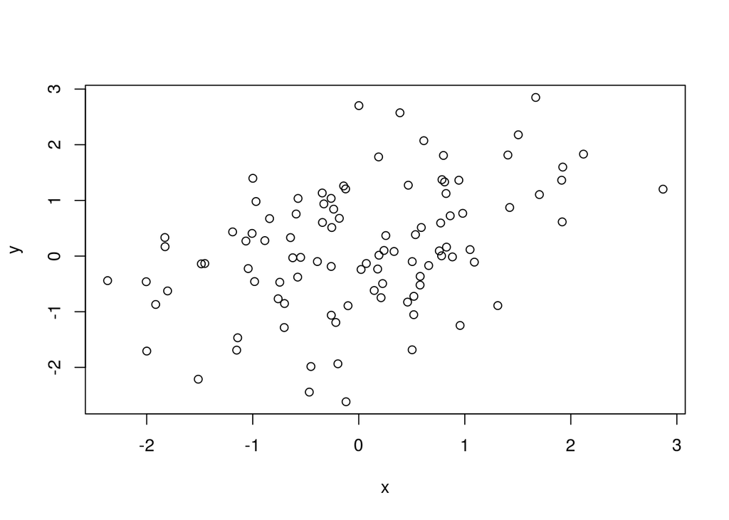

```r
## Fake data 2
set.seed(19)
x <- rnorm(100)
y <- 0.3*x + rnorm(100)
plot(x,y)
```

```r
for (j in 1:sim) {
  idx <- sample(1:100, 100, replace = TRUE)
  out[j] <- cor(y[idx], x[idx])
}



sim <- 100000

out <- array(0, sim)
for (i in 1:sim) {

xbar <- mean(smpl)
out[i] <- sqrt(n)*(xbar-mu)/sqrt(4)
}
```

**Using bootstrap with Cross Validation:**

```r
## Last point exercise


## Bootstrap with cross validation
n <- dim(wage2)[1]
k <- 5 # 5-folds cross validation
h <- 10# Boootstrap h times

mspe <- rep(NA, h) ## null vector to be fill
for (i in 1:h){
## Pick the observations
jj <- sample(1:nrow(wage2), size=nrow(wage2), replace=TRUE)

## Build your new data set
data <- wage2[jj,]

## Now find the MSPE on this new data set!
  ii <- sample(rep(1:k, length= n))
  pr.1 <- rep(NA, n)

  for (j in 1:k){
    hold <- (ii == j)
    train <- (ii != j)
    cc <- tree.control(nobs=nrow(data[train,]), mincut=1, minsize=2,      mindev=exp(-30)) ## Look for other values!
    full <- tree(lwage ~ IQ + educ + exper, data=data[train,], split='deviance',     control=cc)
    tree.cv <- cv.tree(full)
    ko <- max(tree.cv$k[min(tree.cv$dev)==tree.cv$dev])
    pruned.tree <- prune.tree(full, k=ko)
    pr.1[hold] <- predict(pruned.tree, newdata=data[hold,])

}
## Store the MSPE
mspe[i] <- mean((pr.1-data$lwage)^2)
}

## MSPE - > More accurate (less variance)
mean(mspe)
```

```
## [1] 0.1589331
```

```r
## SE(MSPE)

sd(mspe)
```

```
## [1] 0.007532821
```

## Bagging

**Issue with tree**

Tree are highly unstable. In fact one error in one of the first split hugely propagates to the subsequent nodes.

How could we make trees more stable?

**Example**

With simple stumps (1-split trees):

```r
library(tree)
library(rpart)


# bagging on your self


## We use the package rpart, but you may want
## to write your own code using the package tree


set.seed(123)
n <- nrow(wage2)
ii <- sample(n, floor(n/10))

## Build test and training set
dat.te <- wage2[ ii, ]
dat.tr <- wage2[ -ii, ]

# settings to build stumps

stump <- rpart.control(cp=-1,maxdepth=1,minsplit=0,xval=0)

# how many bootstrapped trees to use
N <- 5
# each column contains the predictions
myps <- matrix(NA, nrow(dat.te), N)
n.tr <- nrow(dat.tr)

set.seed(6)
for(j in 1:N) {
  ii <- sample(n.tr, replace=TRUE)
 tmp <- rpart(lwage ~ IQ + educ + exper , data=dat.tr[ii,], control=stump)
myps[,j] <- predict(tmp, newdata=dat.te, type='vector')
}
# predictions on the test set
pr.ba <- rowMeans(myps)
mean((dat.te$lwage - pr.ba)^2)
```

```
## [1] 0.1506949
```

With bigger trees:

```r
set.seed(123)
n <- nrow(wage2)
ii <- sample(n, floor(n/10))
dat.te <- wage2[ ii, ]
dat.tr <- wage2[ -ii, ]

# NEW SETTINGS

huge <- rpart.control(cp=0.001,maxdepth=30,minsplit=50,xval=20)

set.seed(6)
N <- 5
myps <- matrix(NA, nrow(dat.te), N)
n.tr <- nrow(dat.tr)
set.seed(123456)
for(j in 1:N) {
  ii <- sample(n.tr, replace=TRUE)
 tmp <- rpart(lwage ~ IQ + educ + exper , data=dat.tr[ii,], control=huge)
myps[,j] <- predict(tmp, newdata=dat.te, type='vector')
}
pr.ba <- rowMeans(myps)
mean((dat.te$lwage - pr.ba)^2)
```

```
## [1] 0.1358963
```

# Out-of-bag MSE

Cross validation may be computationally expensive with bagging.

Short cut: use the observations left behind from each tree as a test set.

**Method:**

- Bootstrap B times
- Each time build a tree on the new sample
- With each tree make prediction on the out-of-sample observations
- Take the averaged MSPE among all trees

**Example:**

```r
control <- rpart.control(cp=0.001,maxdepth=30,minsplit=50,xval=20)

set.seed(6)
N <- 10
n.tr <- nrow(wage2)
set.seed(12)

## store the predictions
myps <- matrix(NA, nrow(wage2), N)

for(j in 1:N) {
  ii <- sample(n.tr, replace=TRUE)
 tmp <- rpart(lwage ~ IQ + educ + exper , data=wage2[ii,], control=control)
myps[-ii,j] <- predict(tmp, newdata=wage2[-ii,], type='vector')
}

## How many predictions for each tree on average?

(1 - (sum(is.na(myps))/10)/nrow(wage2))
```

```
## [1] 0.3680214
```

```r
## Compute the OOB
pr.ba <- rowMeans(myps, na.rm=TRUE)

##Check if some observations have no predictions
sum(is.na(pr.ba))
```

```
## [1] 5
```

```r
## Store them
kk <- which(is.na(pr.ba))

## remove them
pr.ba <- na.omit(pr.ba)

## Compute the MSPE
mean((wage2$lwage[-kk] - pr.ba)^2)
```

```
## [1] 0.1633741
```

**Do you think the OOB can be compared to the cross-validated MSE?** **Is the size of the bias the same?**

## Random Forest

Trees with bagging can be very similar each other. In the next plots we will try to predict fatalities rate using taxation on beer, unemployment rate, income, the percentage of young drivers and the total number of miles. We want to use a bagging algorithm but before we look at the trees for each bootstrap sample.

**Example:**

```r
set.seed(123)
N <- 3
tmp <- list()
for(j in 1:N) {
  ii <- sample(nrow(fatalities), replace=TRUE)
 tmp[[j]] <- tree(fatal ~ beertax + unemp + milestot + income + youngdrivers , data=fatalities[ii,])

}
```

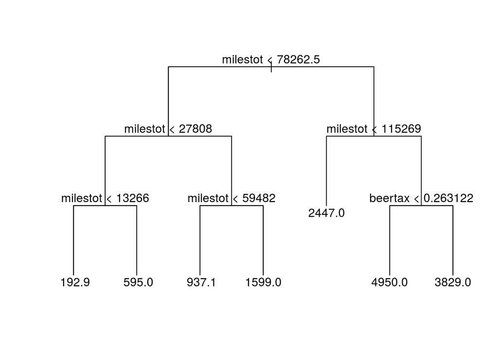

```r
## Three different trees

### First three
plot( tmp[[1]], type='uniform')
text( tmp[[1]], pretty=TRUE)
```

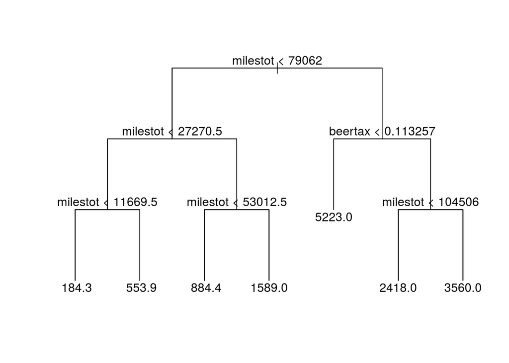

```r
## Second three
plot( tmp[[2]], type='uniform')
text( tmp[[2]], pretty=TRUE)
```

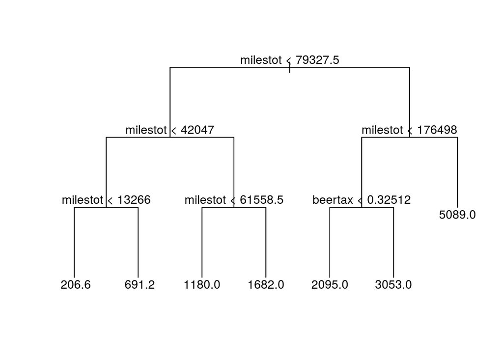

```r
## Third three
plot( tmp[[3]], type='uniform')
text( tmp[[3]], pretty=TRUE)
```

**Do you think bagging can actually improve the performance of a single tree?**

**Random Forest** is a way to decorrelate trees. Given p covariates the algorithm is:

- set m between c(1, p) (default: sqrt(p))
- bootstrap B times (default: 500)
- For each node of each tree pick randomly m covariates and choose the best split
- Take the averaged predictions as your estimator

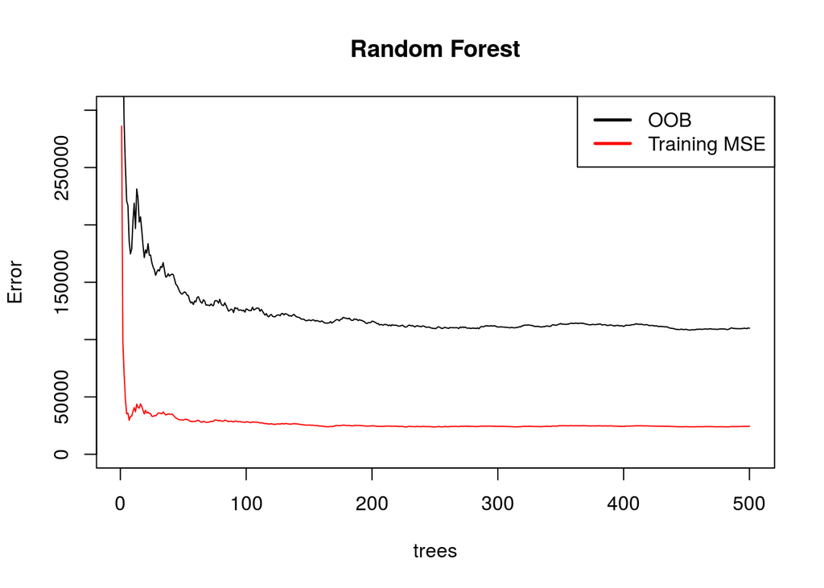

```r
## Example

library(randomForest)
rf <- randomForest(fatal ~ beertax + unemp + milestot + income + youngdrivers , data=fatalities)


## Compare the trainining and test MSE


## Makes prediction on the training set (full set)
rf2 <- randomForest(fatal ~ beertax + unemp + milestot + income + youngdrivers , data=fatalities, xtest=fatalities[,c(7,4,31,5,12)], ytest = fatalities$fatal)


plot(rf2, main="Random Forest" ,  ylim= c(0, 300000))
lines(cbind(c(1:500), rf2$test$mse), col="red")
    legend("topright", legend=c("OOB","Training MSE"),
           cex=1, lwd=c(2.5,2.5),col=c("black","red"))
```

```r
## Compared to simple bagging

control <- rpart.control(cp=0.01,maxdepth=30,minsplit=50,xval=20)

set.seed(6)
N <- 100 ## We use 100 trees!
set.seed(12)
myps <- matrix(NA, nrow(fatalities), N)

for(j in 1:N) {
  ii <- sample(n.tr, replace=TRUE)
 tmp <- rpart(fatal ~ beertax + unemp + milestot + income + youngdrivers , data=fatalities[ii,], control=control)
myps[-ii,j] <- predict(tmp, newdata=fatalities[-ii,], type='vector')
}
pr.ba <- rowMeans(myps, na.rm=TRUE)
mean((fatalities$fatal - pr.ba)^2)
```

```
## [1] 121728.4
```

```r
## Get the OOB of the random forest

rf$mse[which.min(rf$mse)]  ## <- Note the mse is out-of-sample (oob used)
```

```
## [1] 109629.2
```

**Is a random forest only a black box or is there a way to understand the role of covariates?**

## Measuring variables’ importance

**%IncMSE: Permutation importance**

- Standardized mean difference between the test MSE from predictions of each tree computed before and after permuting a given covariate

**IncNodePurity:**

- Total decrease in node impurity (in case of regression MSE) from the splittings of a given variable, averaged over all trees, no matter the position of the node where the split has occurred.

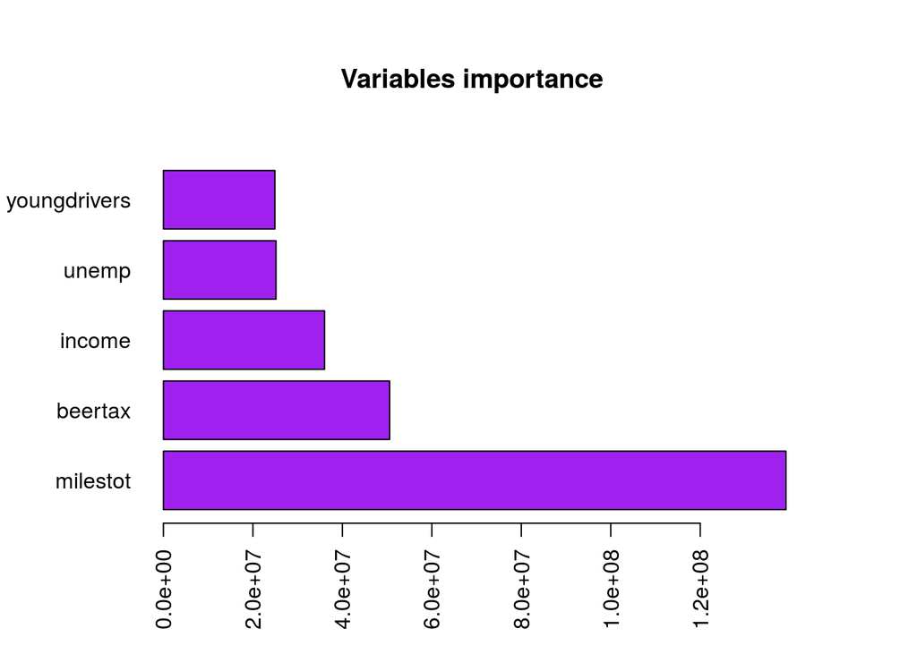

```r
## Analyzing manualy each tree of a forest

a1 <- getTree(rf, k = 1, labelVar = TRUE)
## Display a1 and see your self...

## Short cut to visualize the importance

## Put in order variables for importance
ko <- as.vector(order(rf$importance, decreasing=T)[1:length(rf$importance)])
## Take the names and the values of the variables
names <- rownames(rf$importance)[ko]
values <- rf$importance[ko]
### General settings (try your self....)
par(las=2, mar=c(5,6,6,5))

##Make your plot
barplot(values, names.arg= names ,horiz=TRUE, main="Variables importance", col="purple", cex.names=1)
```

## Exercise

For this exercise you are required to keep using the wage2 data, focusing your attention on lwage as dependent variable.

- Build a bagged model and compute the out-of-sample MSE
- BUild a random forest on a full model
- Compare the two using the OOB MSE
- Look at the variable importance for the random forest

**Then**

- Build a lasso regression on a full model
- Compare the lasso regression with a random forest, looking at the variables selected and at the Out-of-sample MSE (which measure of error would you use?)

**Challenge:**

- Pick the three most important variables of the random forest. Are they positively or negative correlated with lwage?

```r
## Bagging

## Note we use parallel execution in this case


library(foreach)
library(rpart)
## Write your function for bagging

bagging<-function(X, y, x.te = NULL, y.te = NULL, control= rpart.control(minsplit = 20, minbucket = round(minsplit/3)),  trees=100)
{

## If no data test provided it reports the oob MSE
if (is.null(x.te)){
OOB<-foreach(m=1:trees,.combine=cbind) %dopar% {

## Bootstrap and build each tree
ii <- sample(1:length(y), replace=TRUE)
data <- cbind(y, X)
tmp <- rpart(y[ii] ~. , data=data[ii,]) ## Default settings for tree, change on your self it!
vec <- rep(NA, length(y))

## Make your predictions

vec[-ii] <- predict(tmp, newdata=data[-ii,], type='vector')
vec
}

## Store the predictions
pred <- rowMeans(OOB, na.rm=TRUE)

## Check for missing values
kk <- which(is.na(pred))
pred <- na.omit(pred)

  ## Compute the MSE OOB
  if (length(kk)==0){ mean((y - pred)^2) } else { mean((y[-kk] - pred)^2) }

}  else {

  ## Report predictions on the test set if data test is provided

predictions <- foreach(m=1:trees,.combine=cbind) %dopar% {

ii <- sample(1:length(y), replace=TRUE)
data <- cbind(y, X)
data.te <- cbind(y.te, x.te)

## Give the same name to the data test
names(data.te) <- append("y", colnames(X))
tmp <- rpart(y[ii] ~. , data=data[ii,])
predict(tmp, newdata=data.te, type='vector')
}
rowMeans(predictions)
}


}

## Find oob of a full bagged model

X <- wage2[,-c(1,17)]
y <- wage2[,17]
set.seed(123)
oob <- bagging(X=X, y=y, x.te=NULL, y.te= NULL, trees=150) ## try with a test set!
oob
```

```
## [1] 0.1779977
```

```r
## Random Forest (we won't do it by hand, but try yourself using parallel execution...)


library(randomForest)

## Remove all missing values : Is it an efficient way to deal with them?! (try interpolation...)

data <- na.omit(wage2)
set.seed(123)
ranfo <- randomForest(lwage ~., data=data[,-1])

## Smallest OOB

ranfo$mse[which.min(ranfo$mse)]
```

```
## [1] 0.1281272
```

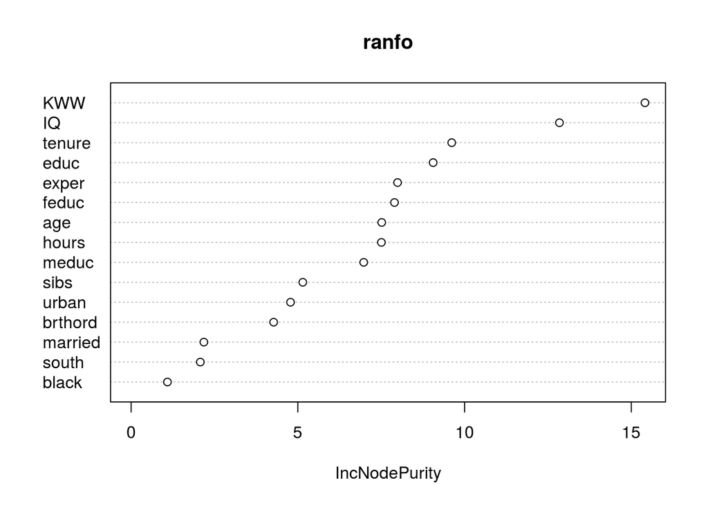

```r
## Use the built-in function to look at variables' importance

varImpPlot(ranfo)
```

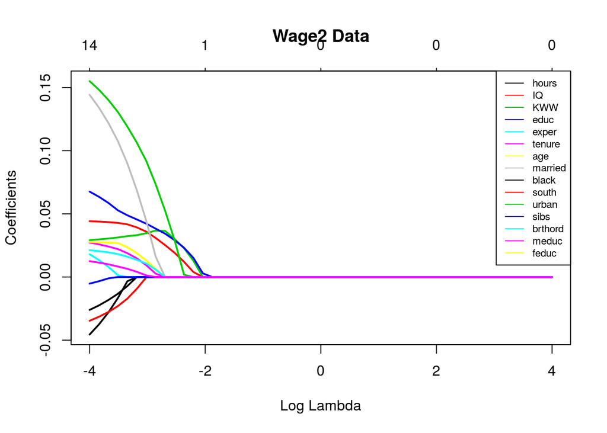

```r
## Second part: building a lasso regression


library(glmnet)
## Expand matrix
xm <- model.matrix(~. ,data=data[,-c(1,17)])[,-1]
y <- data[,17]
## Use this functions to standardize
standard_for_dummy <- function (k){ if (length(k[!duplicated(k)])==2)
{ return(1)}
return(sd(k))                                                      }
sd.tr <- apply(xm, 2, standard_for_dummy)

mu_for_dummy <- function (k){ if (length(k[!duplicated(k)])==2)
{ return(0.5)}
mean(k)      }
mu.tr <-apply(xm, 2, mu_for_dummy)

## New covariate matrix
xmn <- scale(xm, center = mu.tr, scale=sd.tr)

## Set your lambda
lambdas.rr <- exp(seq(-4, 4, length=50))

## Look at the variables
fit <- glmnet(x=as.matrix(xmn), y=y, lambda=lambdas.rr, alpha=1)

## Plot with legend

lbs_fun <- function(fit, ...) {
  L <- length(fit$lambda)
  x <- log(fit$lambda[L])
  y <- fit$beta[, L]
  labs <- names(y)
  legend('topright', legend=labs, col=1:length(labs), lty=1, cex=0.7 )
}
plot(fit, xvar="lambda", col=1:dim(coef(fit))[1], main="Wage2 Data", lwd=2)
lbs_fun(fit)
```

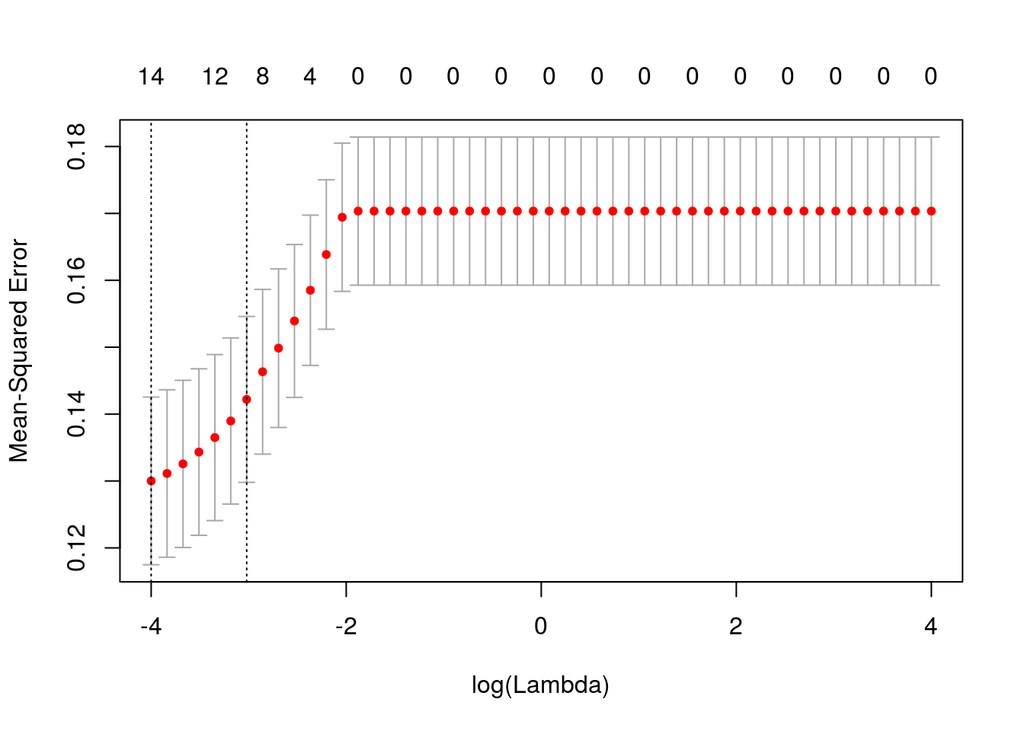

```r
## Build the model choosing lambda with Cross Validation and look at the CV MSE
k <- 10
set.seed(123)
lr.cv <- cv.glmnet(x=as.matrix(xmn), y=y, lambda=lambdas.rr, nfolds=k, alpha=1)
plot(lr.cv)
```

```r
## Can we compare it to the OOb of the random forest....mmmm....


## Let's cross validate!

  data <- na.omit(data)
  k <- 5
  n <- dim(data)[1]
  set.seed(123)
  ii <- sample(rep(1:k, length= n))
  pr.lasso <- rep(NA, n)
  mse.rf <- rep(NA, k)


## Now cross validate
set.seed(123)
 for (j in 1:k){
    hold <- (ii == j)
    train <- (ii != j)

    rf <- randomForest(lwage ~., data=data[train,-1], xtest=data[hold,-c(1,17)], ytest = data[hold, 17])
   mse.rf[j] <- rf$test$mse[which.min(rf$test$mse)]


    lr.cv <- cv.glmnet(x=as.matrix(xmn[train,]), y=y[train], lambda=lambdas.rr, nfolds=k, alpha=1)
    lasso <- glmnet(x=as.matrix(xmn[train,]), y=y[train], lambda=lr.cv$lambda.1se, alpha=1)

    pr.lasso[hold] <- predict(lasso, newx=xmn[hold,])

}

cbind(mean(mse.rf), mean((y-pr.lasso)^2))
```

```
##           [,1]      [,2]
## [1,] 0.1290402 0.1373165
```

```r
## Try to compute the MSPE by bootstrapping and build a confidence interval.. Use parallel execution if you do not want to kill your computer!


## Last point: select 3 most important variables from the random forest and build a linear regression

data <- na.omit(wage2[,-1])
set.seed(123)
ranfo <- randomForest(lwage ~., data=data)
ko <- as.vector(order(ranfo$importance, decreasing=T)[1:3])

## Use only the covariate matrix to match in a right way the order of importance with the variables!

reg <- lm(data$lwage~., data=data[,ko])
summary(reg)
```

```
##
## Call:
## lm(formula = data$lwage ~ ., data = data[, ko])
##
## Residuals:
##      Min       1Q   Median       3Q      Max
## -2.17170 -0.21548 -0.00447  0.25631  1.36997
##
## Coefficients:
##             Estimate Std. Error t value Pr(>|t|)
## (Intercept) 5.691456   0.109592  51.933  < 2e-16 ***
## KWW         0.011233   0.002185   5.141 3.61e-07 ***
## IQ          0.006280   0.001104   5.688 1.93e-08 ***
## tenure      0.010071   0.002968   3.393 0.000733 ***
## ---
## Signif. codes:  0 '***' 0.001 '**' 0.01 '*' 0.05 '.' 0.1 ' ' 1
##
## Residual standard error: 0.3798 on 659 degrees of freedom
## Multiple R-squared:  0.1547, Adjusted R-squared:  0.1509
## F-statistic: 40.21 on 3 and 659 DF,  p-value: < 2.2e-16
```

## Classification trees

**Discussion:**

How could we apply similar algorithms also to classification problems?

Remember from regression trees:

- Semi parametric model
- Greedy algorithm which maximize the “purity” of regions

**Idea:**

- Split data in regions that are clearly dominated from a certain class using still a greedy algorithm

What is the difference from K-NN? Could it suffers for curse of dimensionality?

We define $\hat{p}_{k,m} = \frac{total \space y_k \in R_m}{total \space y \in R_m}$ the estimated probability for the observation of being of class k in a given node $R_m$.

The most homogenous tree would be the one with $\hat{p}_{k,m} = \hat{p}_{j,n} = 1 \space \forall {k,m} \neq {j,n}$, each node with only one class. But of course this plit would lead to overfit.

So we want to set some minimum tresholds:

- Nodes with a minimum number of observations (no trivial splits of only few or one observations)
- Treshold on the gain in terms of deviance

**Measure of purity:**

- Gini Index
- Deviance

Gini Index:

$Q_g = \sum_{j \neq i}^k p_j p_i = \sum_{j = 1}^k p_j (1- p_j)$

Deviance:

$D_g = -2 \sum_{j = 1}^k p_j ln(p_j)$

The two are extremelly similar in practice and we will use the Gini Index.

For each split the algorithm finds:

$$\underset{X_j, a}{\operatorname{argmin}} n_l Q(\{X_j < a\} \in N ) + n_r Q(\{X_j > a\}\in N)$$

Where $n_l$ and $n_r$ are the number of observations in the left and right nodes of a subtree with in total $N$ observations.

De facto, for each split the greedy algorithm minimizes the sum of the impurity multiplied by the size of the new nodes (in order to avoid trivial splits).

## Ensamble techniques

The same techniques used for regression applies to classification, with the only difference that now we have a different measure of “purity”.

Bagging and Random Forest are commonly used to reduce the variance of the predictor.

**Examples:**

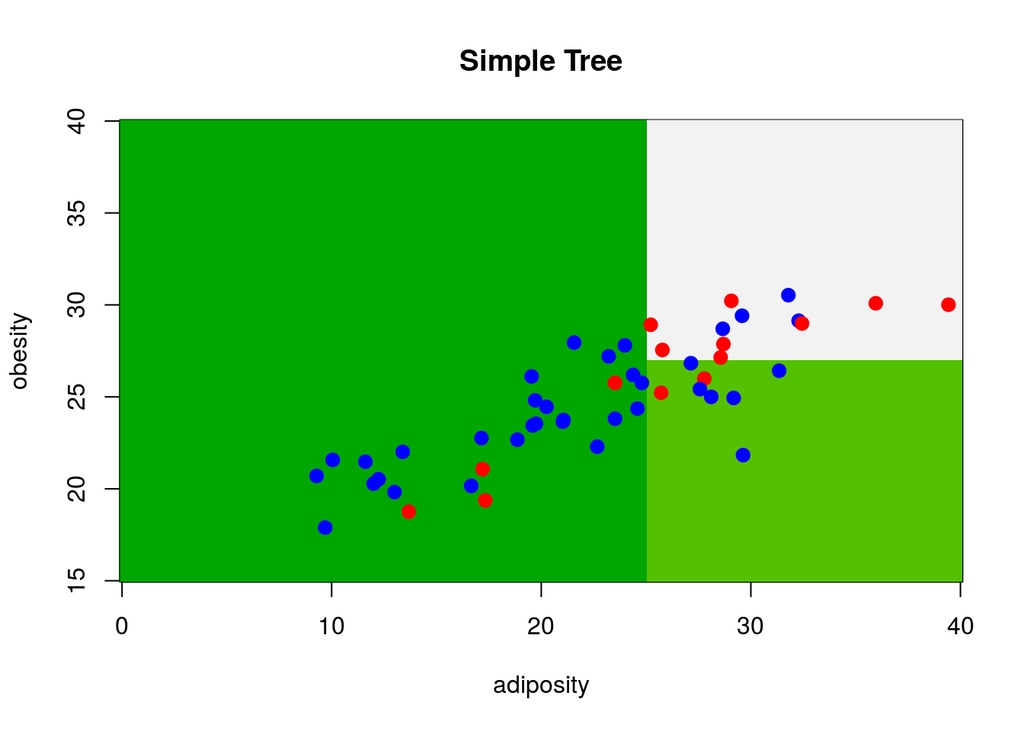

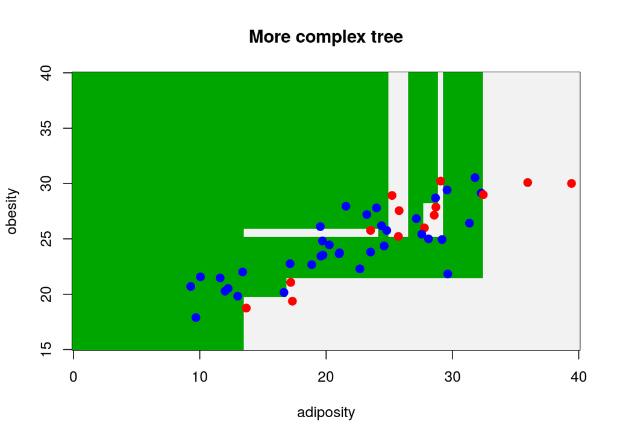

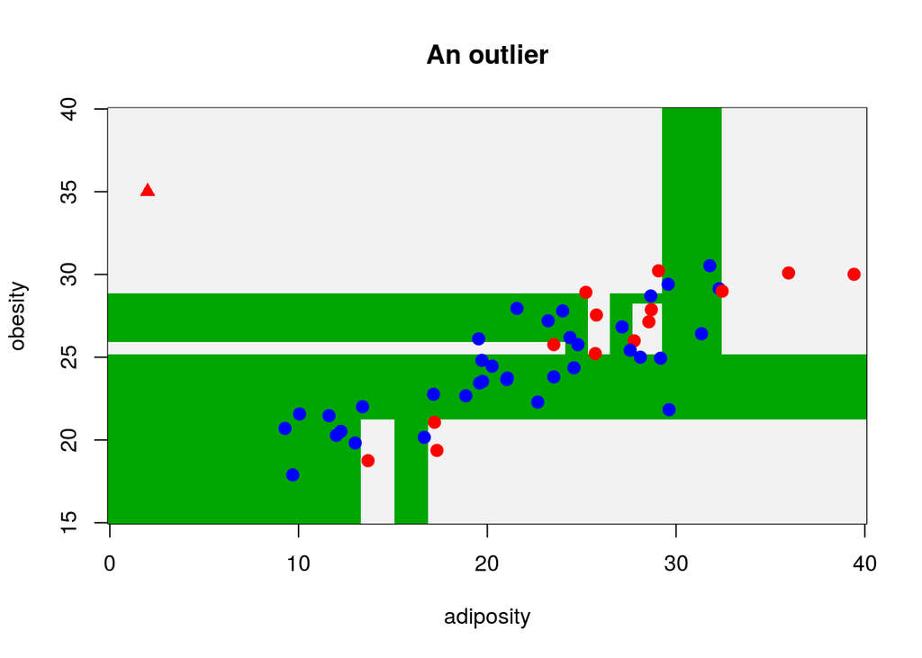

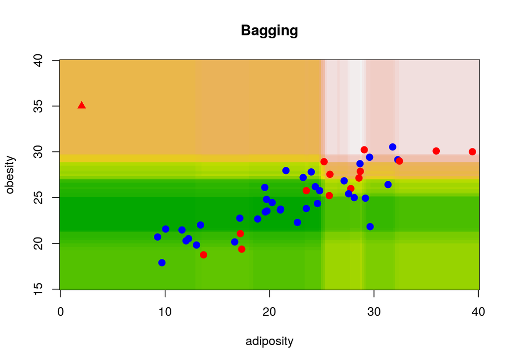

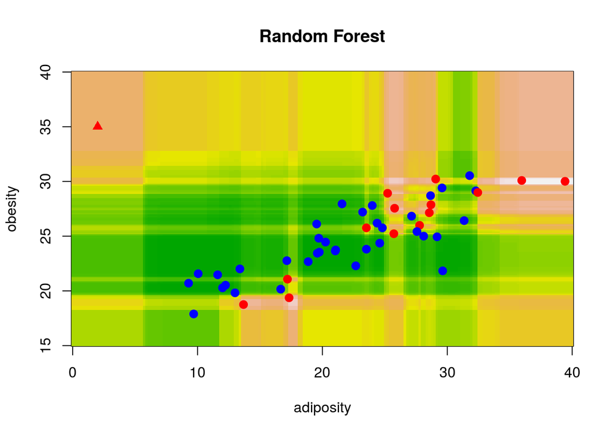

## Exercise

We want to distinguish spam emails from non-spam emails. To do so, we have at disposal a data set with 4601 observations, 57 covariates and the dependent variable equal to one for spam email and zero otherwise.

Explore the data set, provides some statistics regarding the variables and try to understand the main reasoning. Which regression would you use?

- Split data in a test and training set
- Build a bagging algorithm to make predictions on the test set
- Repeat the process with a random forest, compute the test error rate and the OOB error rate

**Challenges:**

- Focus your attention on specificity and sensitivity. Plot a ROC curve and try to maximizes both, choosing a good treshold.
- Baggig by hand: write a function to do bagging with a classification problem. Use parallel execution. (Hint: use the function provided in the solution of the exercise with regression)

```r
library(rpart)

spambase <- read.table("./data/spambase.txt")
spambase$spam <- as.factor(spambase$spam)
set.seed(1)
ii <- sample(1:dim(spambase)[1], replace=FALSE, size= floor(dim(spambase)[1]/5))
data.tr <- spambase[-ii,]
data.te <- spambase[ii,]

x.tr <- data.tr[,-58]
y.tr <- data.tr[,58]
x.te <- data.te[,-58]
y.te <- data.te[,58]

stump <- rpart.control(cp=-1,maxdepth=1,minsplit=0,xval=0)

set.seed(6)
N <- 100 ## We use 100 trees!
set.seed(12)
myps <- matrix(NA, nrow(data.te), N)

for(j in 1:N) {
  ii <- sample(nrow(data.tr), replace=TRUE)
 tmp <- rpart(as.factor(y.tr) ~., data=x.tr[ii,], control=stump)
myps[,j] <- as.numeric(as.character(predict(tmp, newdata=x.te, type='class'))) ##!!
}

## Take the majority vote

pr.ba <- rowMeans(myps, na.rm=TRUE)

## For number lower then 0.5 set 0, 1 otherwis

pr.ba[pr.ba<0.5] <- 0
pr.ba[pr.ba>=0.5] <- 1
mean(y.te != pr.ba)
```

```
## [1] 0.3945652
```

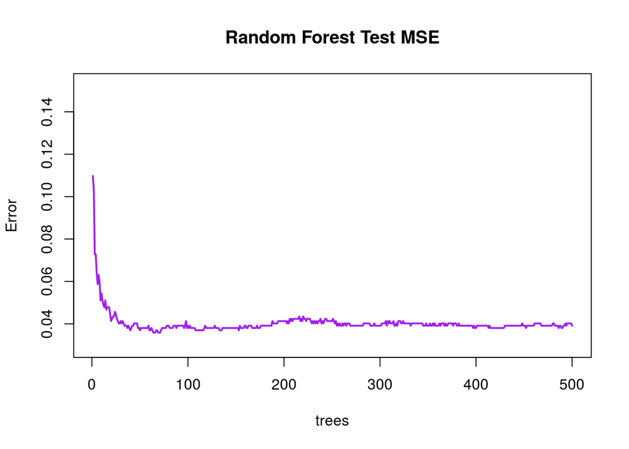

```r
## Change the control setup and see what happens....



## Do with randomforest
library(randomForest)
rf <- randomForest(as.factor(y.tr)~., data = x.tr, xtest = x.te, ytest=as.factor(y.te))

##Plot the Test MSE and the OOB

plot(rf, main="Random Forest Test MSE", type="n")
lines(cbind(c(1:500), rf$test$err.rate), col="purple", lwd=2)
```

```r
## Look at the confusion matrix

rf$test$confusion
```

```
##     0   1 class.error
## 0 549   8  0.01436266
## 1  28 335  0.07713499
```

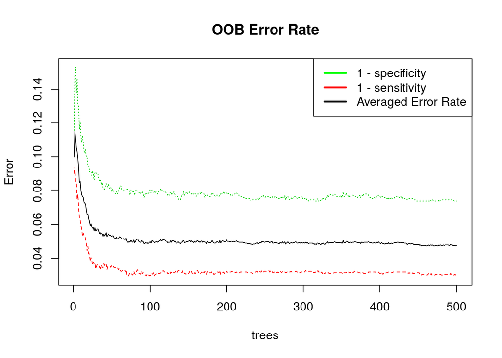

```r
## Plot the oob error rate for each class

plot(rf, main="OOB Error Rate")
 legend("topright", legend=c("1 - specificity","1 - sensitivity", "Averaged Error Rate"),  cex=1, lwd=c(2.5,2.5),col=c("green","red", "black"))
```

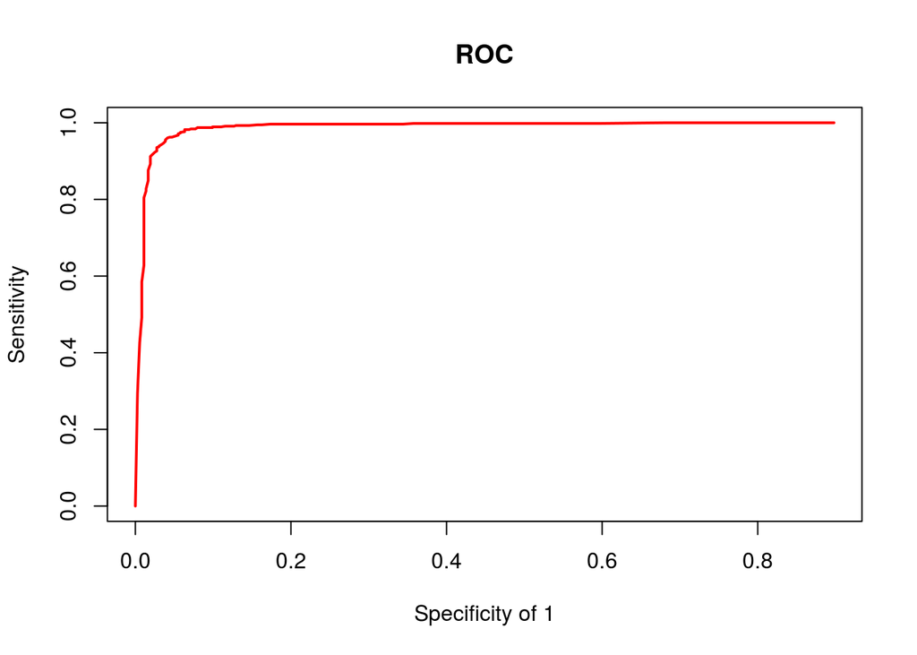

```r
## Plot a ROC curve, remember last lesson...

sensitivity <- spec.1 <- rep(NA, length=length(seq(0,1, by = 0.01)))
k <- 1

## Look at the test set
y <- as.numeric(as.character(y.te)) # Use this trick to be able to make numeric operation with factors
for (i in seq(0,1, by = 0.01)){
pred <-as.numeric(as.character(rf$test$votes[,2])) ## Note I pick votes!!
pred[pred>=i] <- 1
pred[pred<i] <- 0


# Specificity

 sensitivity[k]  <-  sum( (y == 0) & (pred == 0) ) / sum( y == 0)
 spec.1[k] <- (1 - sum( (y == 1) & (pred == 1) ) / sum( y == 1))
  k <- k + 1
  }

plot(cbind(spec.1, sensitivity), type="n", main="ROC", xlab="Specificity of 1", ylab="Sensitivity")
lines(cbind(spec.1, sensitivity), col="red", lwd=2)
```

```r
## First solution: pick the minimum distance from the upper-left corner

## Simply use pitagora's theorem

squared.distances <- (1-sensitivity)^2 + spec.1^2

## Pick the treshold with the minimum distance

tr <- seq(0,1, by = 0.01)[which.min(squared.distances)]


## Make your predictions and look at the new confusion matrix
pred <-as.numeric(as.character(rf$test$votes[,2])) ## Note I pick votes!!
pred[pred>=tr] <- 1
pred[pred<tr] <- 0

confusion <- table(pred, y.te)
class.error <- append(1 - sum( (y.te == 0) & (pred == 0) ) / sum( y.te == 0),
1 - sum( (y.te == 1) & (pred == 1) ) / sum( y.te == 1))


## Compare with 0.5 treshold
cbind(cbind(confusion, class.error), rf$test$confusion)
```

```
##     0   1 class.error   0   1 class.error
## 0 535  15  0.03949731 549   8  0.01436266
## 1  22 348  0.04132231  28 335  0.07713499
```

```r
## Note: this is the most trivial way to find your treshold, find other solutions on yourself...
```

```r
## Challenge 2 : bagging by hand: many solutions are admitted

library(foreach)
library(rpart)
bagging_class <-function(X, y, x.te = NULL, y.te = NULL,  trees=100)
{

## If no data test provided it reports the oob error rate
if (is.null(x.te)){
OOB<-foreach(m=1:trees,.combine=cbind) %dopar% {

## Bootstrap and build each tree
ii <- sample(1:length(y), replace=TRUE)
data <- cbind(y, X)
data$y <- as.factor(data$y)
tmp <- rpart(y[ii] ~. , data=data[ii,])
vec <- rep(NA, length(y))

## Make your predictions

vec[-ii] <- as.numeric(as.character(predict(tmp, newdata=data[-ii,], type="class")))
vec
}

## Take the probability
pred <- rowMeans(OOB, na.rm=TRUE)



## Check for missing values
kk <- which(is.na(pred))
pred <- na.omit(pred)


## Use 0.5 treshold

pred[pred >=0.5] <- 1
pred[pred< 0.5] <-0
  ## Compute the error rate
  if (length(kk)==0){ mean((y != pred)) } else { mean((y[-kk] != pred)) }

}  else {

  ## Report predictions on the test set if data test is provided

predictions <- foreach(m=1:trees,.combine=cbind) %dopar% {

ii <- sample(1:length(y), replace=TRUE)
data <- cbind(y, X)
data.te <- cbind(y.te, x.te)

## Give the same name to the data test
names(data.te) <- append("y", colnames(X))
data$y <- as.factor(data$y)
tmp <- rpart(y[ii] ~. , data=data[ii,])
predict(tmp, newdata=data.te, type='class')
}
## Report probabilities
rowMeans(predictions)
}


}
```

## Boosting

With boosting we will now move away from the case of 0/1 loss function and we will introduce more complex decision boundaries based on different weights given to observations.

**Theoretical Framework**

The loss funcion we have used until now was

$$\frac{1}{N}\sum_{i=1}^n I(y_i \neq g(X_i))$$

But now we want to weight errors according to the distance between the predicted posterior probability and the true class of the observation.

A general definition for a predictor may be:

$$g(x_i,\theta) = \sum_{j=1}^k \beta_j f(x_i, \gamma_j)$$

With $\theta_j$ = ($\beta_j$, $\gamma_j$) . For a linear regression function $f(x_i,\gamma_j) = x_{j,i}$, while in other cases such as basis expansion models the function can be much more complex. Given $\Lambda(y_i, f(x_i,\theta_j))$ a certain loss function we would like to solve:

$$\theta = \underset{\beta,\gamma}{\operatorname{argmin}} \sum_{i=1}^n \Lambda(y_i, \sum_{j=1}^k \beta_j f(x_i, \gamma_j))$$

Unfortunately this is a very complex problem. There are many short-cuts to avoid this impossible computation. An approximation can be done by fixing a certain function $f$ and use a stepwise algorithm. In this case the problem becomes:

$$\theta = \underset{\beta,\gamma}{\operatorname{argmin}} \sum_{i=1}^n \Lambda(y_i, f_{j-1}(x_i) + \beta_j f(x_i,\gamma_j))$$

where $f_j = f_{j-1}(x_i) + \beta_j f(x_i,\gamma_j)$.

Adaboost is a weak learner algorithm very similar to *forward* stagewise which uses a particular loss function.

We first define a new loss:

$$L(y, g(x)) = e^{-yg(x)}$$

What is the intuition?

With this new function the basis expansion becomes:

$$\theta = \underset{\beta,G}{\operatorname{argmin}} \sum_{i=1}^n exp(- y_i( f_{j-1}(x_i) + \beta G(x_i))$$

At each step $m$ the classifier $G_m$ and $\beta$ are computed. This can be written as

$$\theta = \underset{\beta,G}{\operatorname{argmin}} \sum_{i=1}^n w_i^{(m)}exp(- \beta y_i G(x_i))$$

where $w_i^{(m)} = exp(- y_i f(x_i)_{m - 1})$. Note that the weights do not depends on the parameter and , in this case, the problem is solvable.

For any $\beta > 0$ the solution can be written as (HFT, pag. 343)

$$G(x) = \underset{G}{\operatorname{argmin}} \sum_{i=1}^n w_i^{(m)}I(y_i \neq g(X_i))$$

And plugging the solution in the f.o.c. (we are dealing each time with a convex problem)

$$\beta = \frac{1}{2} log \frac{1 - err_m}{err_m}$$

Where $err_m$ is the minimized weighted error rate

$$\frac{\sum_{i=1}^n w_i^{(m)}I(y_i \neq g(X_i))}{\sum_{i=1}^n w_i^{(m)}}$$

**In practice**

1. Initialize the observations with same weights ($\frac{1}{N}$)
2. from m in 1:M
   - fit $G(x)_m$ using the actual weights
   - compute $err_m = \frac{\sum_{i=1}^n w_i^{(m)}I(y_i \neq g(X_i))}{\sum_{i=1}^n w_i^{(m)}}$
   - compute $\alpha_m = log \frac{1 - err_m}{err_m}$
   - set $w_{i,m+1} : = w_{i,m} exp(\alpha_m I(y_i \neq g(X_i)))$
3. Predictor: $G(x)_m = sign[\sum_{m=1}^M \alpha_m G_m(x)]$

Note that $G(x)$ is generally a tree, but you can use the same algorithm with other functions.

**What are we estimating?**

The population solution of a classification problem with exponential loss is:

$$f*(x) = \underset{f(x)}{\operatorname{argmin}} E_{Y|X}[exp(-Yf(x))]$$

It is trivial to show in a two-class scenario that this number is equal to: $\frac{1}{2} log\frac{P(Y=1|X)}{P(Y \neq 1|X)}$

The same result applies to other losses such as the deviance. It means that asyntadically different losses may have similar results. But with approximations…

**Issues:**

- How many interations?
- What is the best size of the tree?

Note:

- The deepest the tree, the higher the level of interactions between variables. If the “real” $f(x)$ is characterized by many interations boosting may work only with many-nodes trees, while if there are no interetions stumps may perform extremelly well.
- The algorithm does not converge by definition and the evolution of the error can be more unstable compared to other algorithms.

**Example**

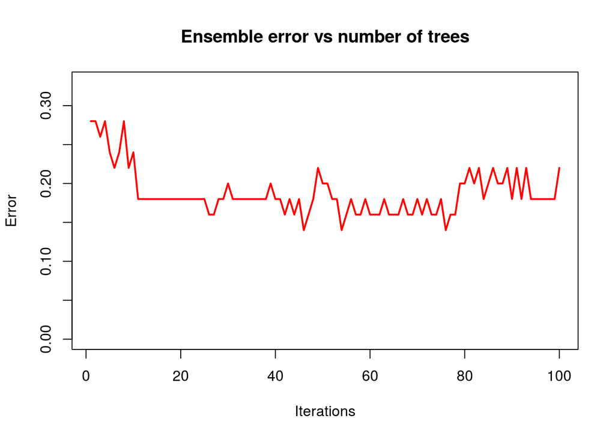

```r
library(adabag)
library(rpart)

heart_train <- read.table("./data/heart_train.txt")
heart_test <- read.table("./data/heart_test_with_y.txt")
## heart data test and training set

## With stumps

stump <- rpart.control(cp=-1,maxdepth=1,minsplit=0,xval=0)
heart_train$chd <- as.factor(heart_train$chd)
heart_test$chd <- as.factor(heart_test$chd)

heart_train <- na.omit(heart_train)
set.seed(1)
bb <- boosting(chd~., data=heart_train, boos = FALSE, mfinal = 100, coeflearn = 'Breiman', control=stump)


## Be careful to the test set...


err_te <- errorevol(bb, newdata=heart_test)


plot(err_te, lwd=2)
```

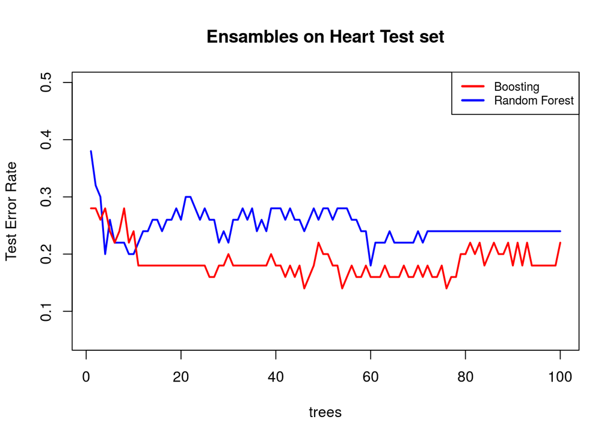

```r
## Change the tree

contr <- rpart.control(cp=exp(-50),maxdepth=30,minsplit=0)


## Comparing with a random forest

rr <- randomForest(heart_train$chd~., data=heart_train[,-11], tree=100, xtest=heart_test[,-c(1,11)], ytest = heart_test[,11])

plot(cbind(c(1:100), err_te$error), main= "Ensambles on Heart Test set", type="n", ylim=c(0.05, 0.50), xlab="trees", ylab="Test Error Rate")
lines(cbind(c(1:100), rr$test$err.rate[c(1:100),1]), col="blue", lwd=2)
lines(cbind(c(1:100), err_te$error), col="red", lwd=2)

 legend("topright", legend=c("Boosting","Random Forest"), cex=0.8, lwd=c(2.5,2.5),col=c("red","blue"))
```

## Exercise

During this exercise we will generate data to understand the performance of Adabag in several circumstances.

**Then:**

- Set $y \sim V1*V2*V3 + 3V2 + 2V3 + V10^2*V4*V9 + exp(V5) + sin(V1)$
- Is boosting a suitable algorithm using stumps?
- Can you explain which kind of trees would you choose?

**Solution**

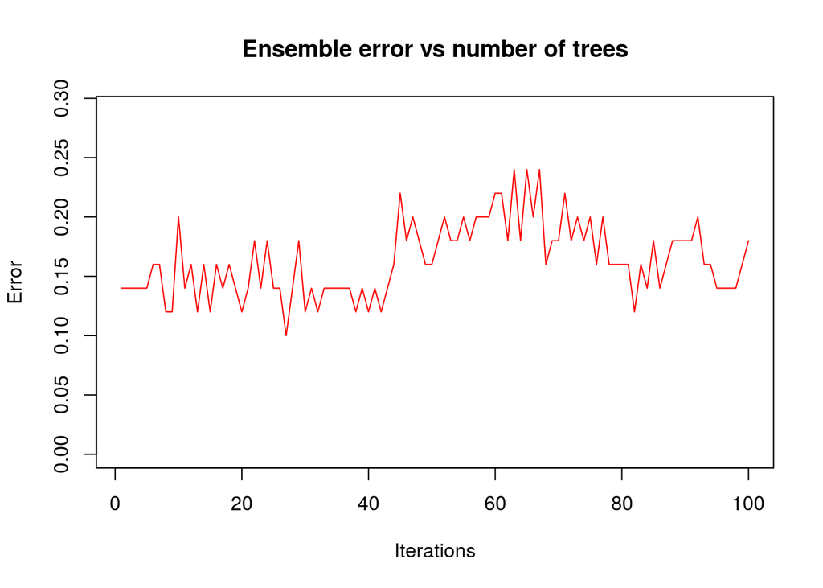

```r
set.seed(123)
X <- matrix(0, 300, 10)
for (i in 1:10){
  X[,i] <- runif(300,-1,1)
}


y <- X[,1] + 3*X[,2] + rnorm(300)
y <- ifelse(y>=0, 1, 0)

set.seed(123)
ii <- sample(1:nrow(X), replace=FALSE, size=50)
stump <- rpart.control(cp=-1,maxdepth=1,minsplit=0,xval=0)
data <- as.data.frame(cbind(y,X))
data$y <- as.factor(data$y)

data.test <- data[ii,]
data.train <- data[-ii,]

set.seed(123)
bb <- boosting(y~., data=data.train, boos = FALSE, mfinal = 100, coeflearn = 'Freund', control=stump)

err_te <- errorevol(bb, newdata=data.test)

plot(err_te)
```

```r
##Training

mean(bb$class != data.train$y)
```

```
## [1] 0.028
```

```r
## Test

err_te$error[which.min(err_te$error)]
```

```
## [1] 0.1
```

```r
## Change control tree

bigger <- rpart.control(cp=-1,maxdepth=10,minsplit=1,xval=0)


bb2 <- boosting(y~., data=data.train, boos = FALSE, mfinal = 100, coeflearn = 'Freund', control=bigger)

## Training

mean(bb2$class != data.train$y)
```

```
## [1] 0
```

```r
## Test....


predict(bb2, newdata=data.test)$error
```

```
## [1] 0.16
```

```r
### Second part of the exercise

y <- X[,1]*X[,2]*X[,3] + 3*X[,2] + 2*X[,3] + X[,10]^2* X[,4]*X[,9] + exp(X[,5]) + sin(X[,1]) + rnorm(300)
y <- ifelse(y>=0, 1, 0)

## Repeat everything...


ii <- sample(1:nrow(X), replace=FALSE, size=50)
stump <- rpart.control(cp=-1,maxdepth=1,minsplit=0,xval=0)
data <- as.data.frame(cbind(y,X))
data$y <- as.factor(data$y)

data.test <- data[ii,]
data.train <- data[-ii,]

set.seed(123)
bb <- boosting(y~., data=data.train, boos = FALSE, mfinal = 100, coeflearn = 'Freund', control=stump)
err_te <- errorevol(bb, newdata=data.test)

## Change control tree
bigger <- rpart.control(cp=-1,maxdepth=2,minsplit=1,xval=0)

bb2 <- boosting(y~., data=data.train, boos = FALSE, mfinal = 100, coeflearn = 'Freund', control=bigger)

## See predict with boosting, larger trees capture the interactions...

cbind(predict(bb, newdata=data.test)$error, predict(bb2, newdata=data.test)$error)
```

```
##      [,1] [,2]
## [1,] 0.12  0.1
```